# laboratorio Professor Heitor

```r
summary(cdc)
```

```
##       genhlth        exerany          hlthplan         smoke100
##  excellent:4657   Min.   :0.0000   Min.   :0.0000   Min.   :0.0000
##  very good:6972   1st Qu.:0.0000   1st Qu.:1.0000   1st Qu.:0.0000
##  good     :5675   Median :1.0000   Median :1.0000   Median :0.0000
##  fair     :2019   Mean   :0.7457   Mean   :0.8738   Mean   :0.4721
##  poor     : 677   3rd Qu.:1.0000   3rd Qu.:1.0000   3rd Qu.:1.0000
##                   Max.   :1.0000   Max.   :1.0000   Max.   :1.0000
##      height          weight         wtdesire          age        gender
##  Min.   :48.00   Min.   : 68.0   Min.   : 68.0   Min.   :18.00   m: 9569
##  1st Qu.:64.00   1st Qu.:140.0   1st Qu.:130.0   1st Qu.:31.00   f:10431
##  Median :67.00   Median :165.0   Median :150.0   Median :43.00
##  Mean   :67.18   Mean   :169.7   Mean   :155.1   Mean   :45.07
##  3rd Qu.:70.00   3rd Qu.:190.0   3rd Qu.:175.0   3rd Qu.:57.00
##  Max.   :93.00   Max.   :500.0   Max.   :680.0   Max.   :99.00
```

```r
names(cdc)
```

```
## [1] "genhlth"  "exerany"  "hlthplan" "smoke100" "height"   "weight"
## [7] "wtdesire" "age"      "gender"
```

```r
head(cdc)
```

```
##     genhlth exerany hlthplan smoke100 height weight wtdesire age gender
## 1      good       0        1        0     70    175      175  77      m
## 2      good       0        1        1     64    125      115  33      f
## 3      good       1        1        1     60    105      105  49      f
## 4      good       1        1        0     66    132      124  42      f
## 5 very good       0        1        0     61    150      130  55      f
## 6 very good       1        1        0     64    114      114  55      f
```

```r
tail(cdc)
```

```
##         genhlth exerany hlthplan smoke100 height weight wtdesire age
## 19995      good       0        1        1     69    224      224  73
## 19996      good       1        1        0     66    215      140  23
## 19997 excellent       0        1        0     73    200      185  35
## 19998      poor       0        1        0     65    216      150  57
## 19999      good       1        1        0     67    165      165  81
## 20000      good       1        1        1     69    170      165  83
##       gender
## 19995      m
## 19996      f
## 19997      m
## 19998      f
## 19999      f
## 20000      m
```

```r
summary(cdc$weight)
```

```
##    Min. 1st Qu.  Median    Mean 3rd Qu.    Max.
##    68.0   140.0   165.0   169.7   190.0   500.0
```

```r
mean(cdc$weight)
```

```
## [1] 169.683
```

```r
var(cdc$weight)
```

```
## [1] 1606.484
```

```r
median(cdc$weight)
```

```
## [1] 165
```

```r
table(cdc$smoke100)
```

```
##
##     0     1
## 10559  9441
```

```r
table(cdc$smoke100)/20000
```

```
##
##       0       1
## 0.52795 0.47205
```

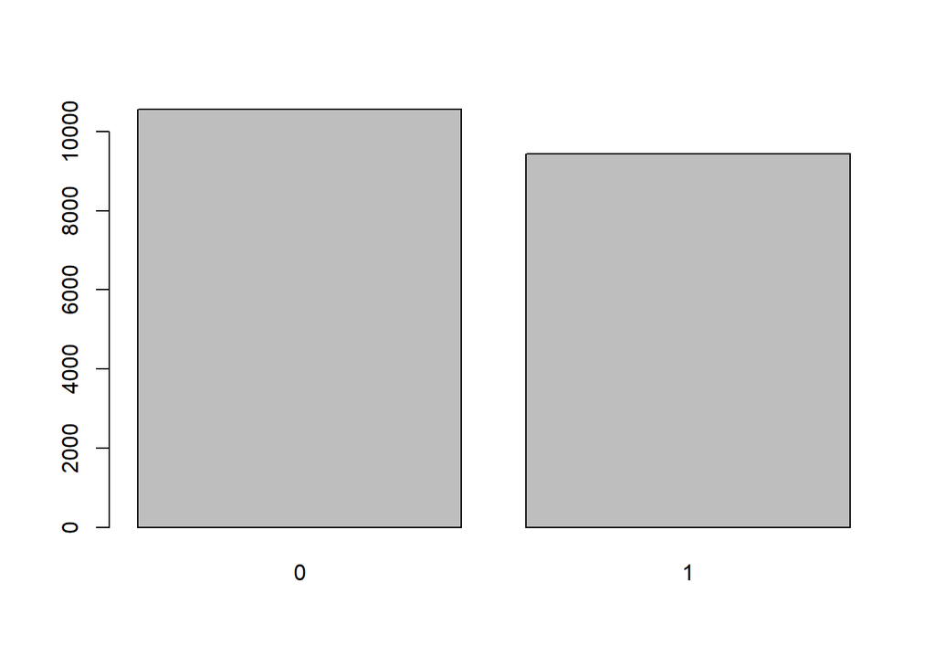

```r
barplot(table(cdc$smoke100))

smoke <- table(cdc$smoke100)

barplot(smoke)
```

```r
# genhlth, os respondentes foram indagados sobre sua saúde geral, respondendo excelente, muito, bom, bom, razoável ou ruim.
# exerany indica se o respondente se exercitou no último mês (1) ou não (0).
# hlthplan indica se o respondente tem alguma forma de cobertura (1) ou não (0).
# smoke100 indica se o respondente fumou pelo menos 100 cigarros ao longo da vida.
# height altura em polegadas,
# weight o peso em libras
# wtdesire peso desejado,
# age idade em anos
# gender gênero masculino ou feminino
```

## Exercício 1

Há quantos casos neste conjunto de dados?

20 000

Quantas variáveis?

9

Para cada variável, identifique seu tipo de dado (p.e., categorial, discreta).

Anotações Giseldo : O tipo de atributo pode ser do grupo categorico (ou qualitativo) ou do grupo Númerico (ou quantitativo). Se ele for do grupo categorico (ou númerico) pode ser do tipo nominal ou ordinal. Se numero for do grupo númerico (ou quantitativo) pode ser do tipo Intervalar ou Racional. Quanto a taxonomia ele pode ser Discreto ou Contínuo.

genhlth (good, very good, …) : categorico (ou qualitativo) do tipo nominal. Taxonomia: Discreto

exerany (0 ou 1) : categorico (ou qualitativo) do tipo nominal. Taxonomia: Discreto

hlthplan (0 ou 1) : categorico (ou qualitativo) do tipo nominal.Taxonomia: Discreto

smoke100 (0 ou 1) : categorico (ou qualitativo) do tipo nominal.Taxonomia: Discreto

height (altura) : Númerico (ou quantitativo) do tipo razão. Taxonomia Contínuo

weight (peso) : Númerico (ou quantitativo) do tipo razão. Taxonomia Contínuo

wtdesire (peso) : Númerico (ou quantitativo) do tipo razão. Taxonomia Contínuo

age (idade) : Númerico (ou quantitativo) do tipo razão. Taxonomia Contínuo

gender (f ou m) : categorico (ou qualitativo) do tipo nominal.Taxonomia: Discreto

```r
names(cdc)
```

```
## [1] "genhlth"  "exerany"  "hlthplan" "smoke100" "height"   "weight"
## [7] "wtdesire" "age"      "gender"
```

```r
dim(cdc)
```

```
## [1] 20000     9
```

```r
## Class
class(cdc$genhlth)
```

```
## [1] "factor"
```

```r
class(cdc$exerany)
```

```
## [1] "numeric"
```

```r
class(cdc$hlthplan)
```

```
## [1] "numeric"
```

```r
class(cdc$smoke100)
```

```
## [1] "numeric"
```

```r
class(cdc$height)
```

```
## [1] "numeric"
```

```r
class(cdc$wtdesire)
```

```
## [1] "integer"
```

```r
class(cdc$age)
```

```
## [1] "integer"
```

```r
class(cdc$gender)
```

```
## [1] "factor"
```

```r
## Typeof
typeof(cdc$genhlth)
```

```
## [1] "integer"
```

```r
typeof(cdc$exerany)
```

```
## [1] "double"
```

```r
typeof(cdc$hlthplan)
```

```
## [1] "double"
```

```r
typeof(cdc$smoke100)
```

```
## [1] "double"
```

```r
typeof(cdc$height)
```

```
## [1] "double"
```

```r
typeof(cdc$wtdesire)
```

```
## [1] "integer"
```

```r
typeof(cdc$age)
```

```
## [1] "integer"
```

```r
typeof(cdc$gender)
```

```
## [1] "integer"
```

### Exercício 2

Crie um sumário numérico para height (altura) e age (idade), e calcule o intervalo interquartílico para cada um.

altura

Min. 1st Qu. Median Mean 3rd Qu. Max. 48.00 64.00 67.00 67.18 70.00 93.00

idade

Min. 1st Qu. Median Mean 3rd Qu. Max. 18.00 31.00 43.00 45.07 57.00 99.00

Calcule a distribuição de frequência relativa (o que é frequencia relativa?) para gender e exerany.

Quantos homens compõem a amostra?

9569 Homens

Qual proporção da amostra diz estar com saúde excelente?

4657 Pessoas

```r
  # sumary
  summary(cdc$height)
```

```
##    Min. 1st Qu.  Median    Mean 3rd Qu.    Max.
##   48.00   64.00   67.00   67.18   70.00   93.00
```

```r
  summary(cdc$age)
```

```
##    Min. 1st Qu.  Median    Mean 3rd Qu.    Max.
##   18.00   31.00   43.00   45.07   57.00   99.00
```

```r
  head(cdc)
```

```
##     genhlth exerany hlthplan smoke100 height weight wtdesire age gender
## 1      good       0        1        0     70    175      175  77      m
## 2      good       0        1        1     64    125      115  33      f
## 3      good       1        1        1     60    105      105  49      f
## 4      good       1        1        0     66    132      124  42      f
## 5 very good       0        1        0     61    150      130  55      f
## 6 very good       1        1        0     64    114      114  55      f
```

```r
  # gender
  head(cdc$gender)
```

```
## [1] m f f f f f
## Levels: m f
```

```r
  gender <- table(cdc$gender)
  gender
```

```
##
##     m     f
##  9569 10431
```

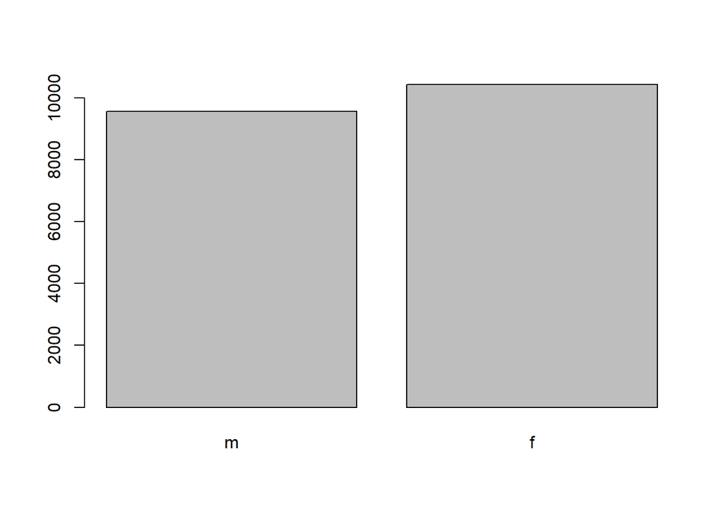

```r
  barplot(gender)
```

```r
  # exerany
  exerany <- table(cdc$exerany)
  exerany
```

```
##
##     0     1
##  5086 14914
```

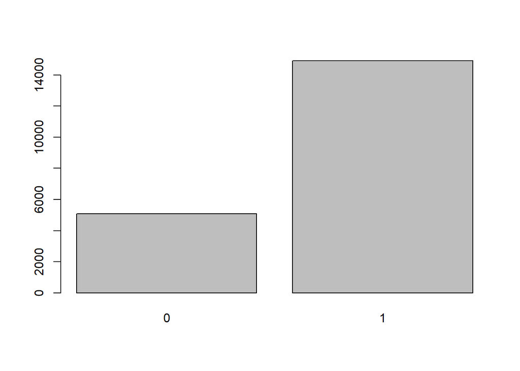

```r
  barplot(exerany)
```

```r
  # genhlth
  genhlth <- table(cdc$genhlth)
  genhlth
```

```
##
## excellent very good      good      fair      poor
##      4657      6972      5675      2019       677
```

### Exercício 3

O que o gráfico de mosaico revela sobre os hábitos de fumar e gênero?

Que os homens fumam mais de 100 cigarros do que as mulheres.

```r
  table(cdc$gender, cdc$smoke100)
```

```
##
##        0    1
##   m 4547 5022
##   f 6012 4419
```

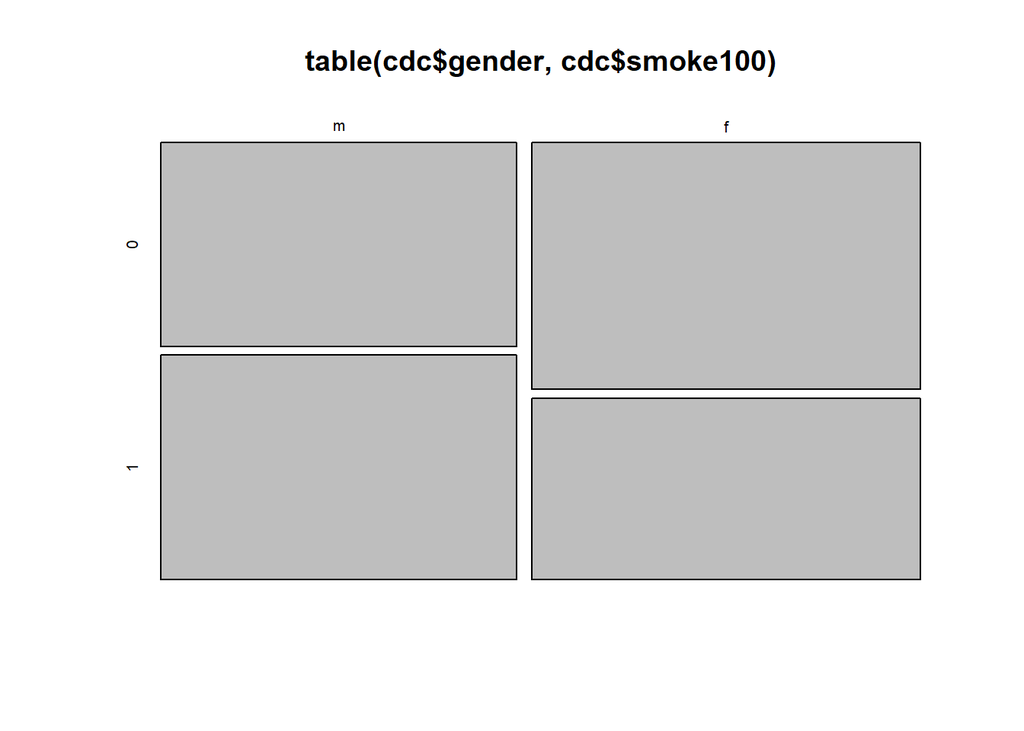

```r
  mosaicplot(table(cdc$gender, cdc$smoke100))
```

Que os homens fumam mais de 100 cigarros do que as mulheres.

```r
  dim(cdc)
```

```
## [1] 20000     9
```

```r
  cdc[567,6]
```

```
## [1] 160
```

```r
  names(cdc)
```

```
## [1] "genhlth"  "exerany"  "hlthplan" "smoke100" "height"   "weight"
## [7] "wtdesire" "age"      "gender"
```

```r
  cdc[1:10,6]
```

```
##  [1] 175 125 105 132 150 114 194 170 150 180
```

```r
  cdc[1:10,]
```

```
##      genhlth exerany hlthplan smoke100 height weight wtdesire age gender
## 1       good       0        1        0     70    175      175  77      m
## 2       good       0        1        1     64    125      115  33      f
## 3       good       1        1        1     60    105      105  49      f
## 4       good       1        1        0     66    132      124  42      f
## 5  very good       0        1        0     61    150      130  55      f
## 6  very good       1        1        0     64    114      114  55      f
## 7  very good       1        1        0     71    194      185  31      m
## 8  very good       0        1        0     67    170      160  45      m
## 9       good       0        1        1     65    150      130  27      f
## 10      good       1        1        0     70    180      170  44      m
```

```r
  #cdc[,6]

  cdc$weight[1:10]
```

```
##  [1] 175 125 105 132 150 114 194 170 150 180
```

```r
  # cdc$gender == "m"

  # cdc$age > 30

  mdata <- subset(cdc, cdc$gender == "m")

  head(mdata)
```

```
##      genhlth exerany hlthplan smoke100 height weight wtdesire age gender
## 1       good       0        1        0     70    175      175  77      m
## 7  very good       1        1        0     71    194      185  31      m
## 8  very good       0        1        0     67    170      160  45      m
## 10      good       1        1        0     70    180      170  44      m
## 11 excellent       1        1        1     69    186      175  46      m
## 12      fair       1        1        1     69    168      148  62      m
```

```r
  m_and_over30 <- subset(cdc, cdc$gender == "m" & cdc$age >30)

  dim(m_and_over30)
```

```
## [1] 7244    9
```

### Exercício 4

Crie um novo objeto denominado under23_and_smoke (ou, se preferir, abaixo23_e_fuma) que contém todas as observações dos respondentes com menos de 23 anos que fumaram pelo menos 100 cigarros ao longo de sua vida. Escreva o comando que você utilizou para criar o novo objeto como resposta para esse exercício.

abaixo23_e_fuma = subset(cdc, cdc$age < 23 & cdc$smoke100 ==1)

dim(abaixo23_e_fuma)

```r
  abaixo23_e_fuma = subset(cdc, cdc$age < 23 & cdc$smoke100 ==1)

  dim(abaixo23_e_fuma)
```

```
## [1] 620   9
```

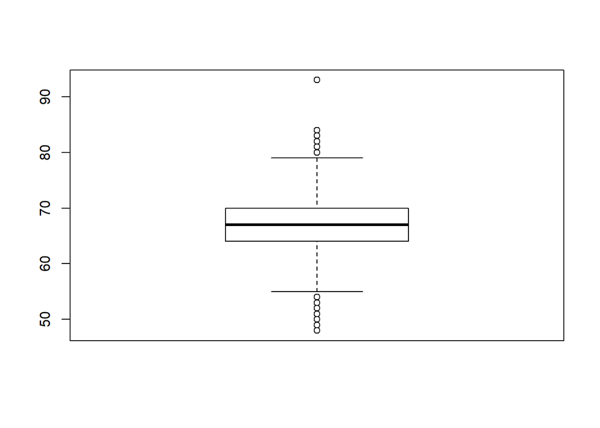

```r
  boxplot(cdc$height)
```

```r
  summary(cdc$height)
```

```
##    Min. 1st Qu.  Median    Mean 3rd Qu.    Max.
##   48.00   64.00   67.00   67.18   70.00   93.00
```

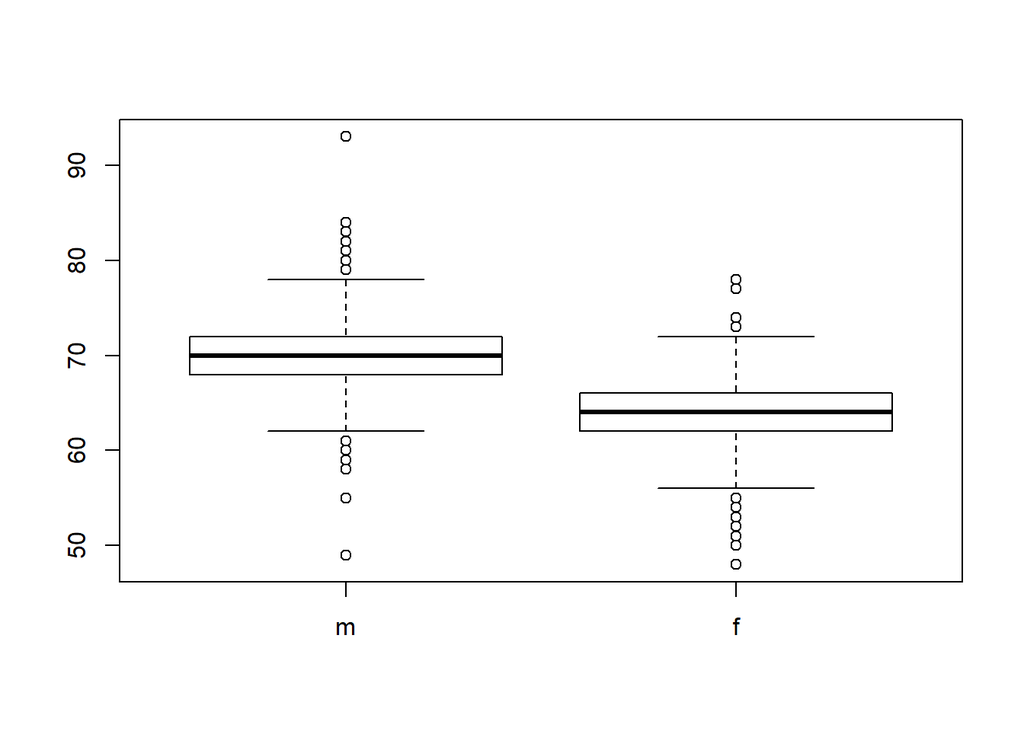

```r
  boxplot(cdc$height ~ cdc$gender)
```

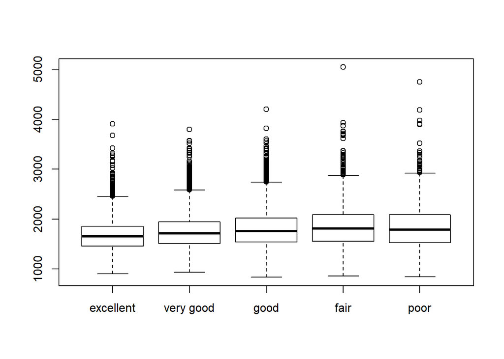

```r
  bmi <- (cdc$weight / cdc$height) * 703

  boxplot(bmi ~ cdc$genhlth)
```

# Exercício 5

O que este gráfico de caixas mostra?

Escolha outra variável categorial do conjunto de dados e verifique como ela se relaciona ao IMC. Liste a variável que você escolheu, por que você pensou que ela poderia ter relação com o IMC e indique o que o gráfico parece sugerir.

Quem fuma mais de 100 cigarros (smoke100) o gráfico sugere que não há uma relação entre o BMI/IMC com o cigarro.

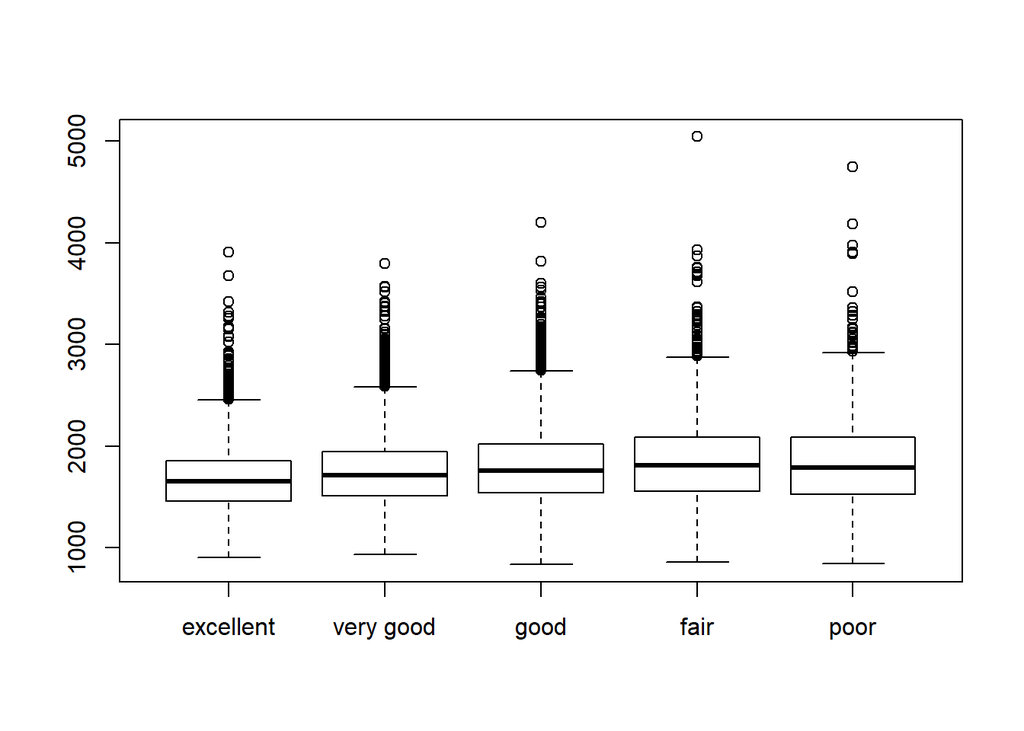

```r
  # saude geral
  boxplot(bmi ~ cdc$genhlth)
```

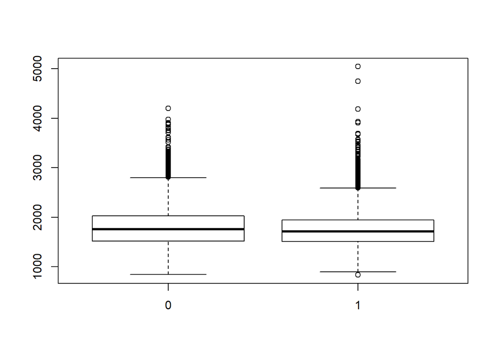

```r
  # se exercita
  boxplot(bmi ~ cdc$exerany)
```

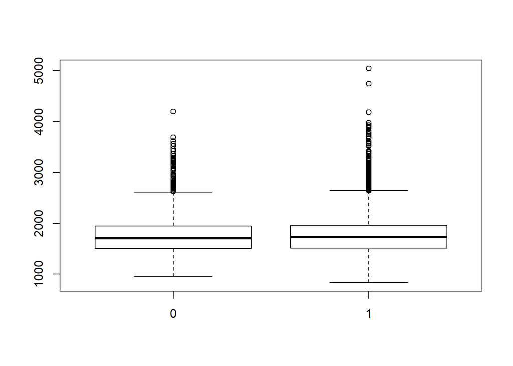

```r
  # tem plano de saude
  boxplot(bmi ~ cdc$hlthplan)
```

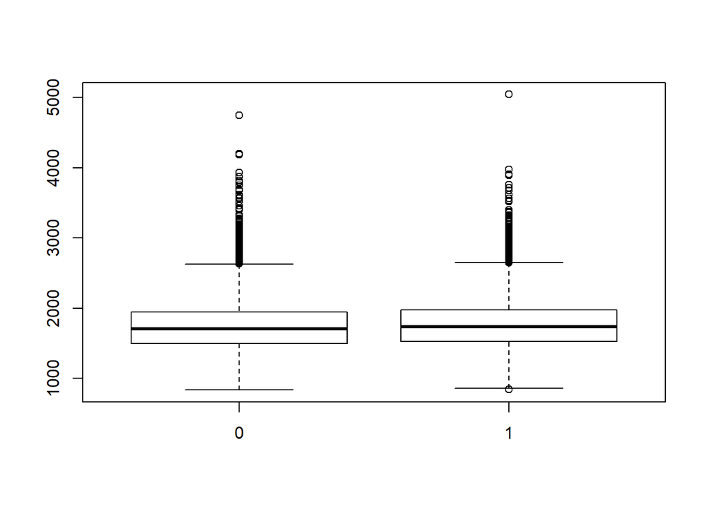

```r
  # fuma
  boxplot(bmi ~ cdc$smoke100)
```

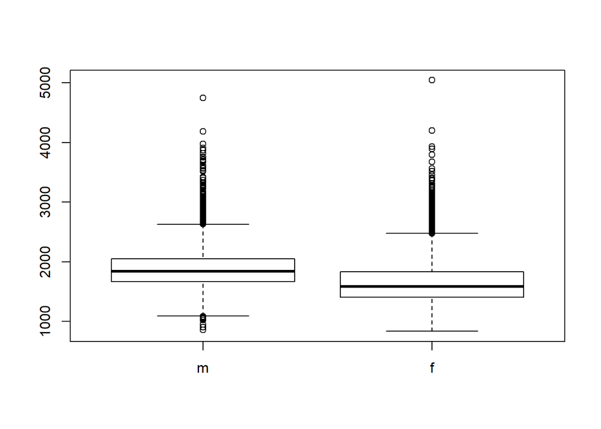

```r
  # sexo
  boxplot(bmi ~ cdc$gender)
```

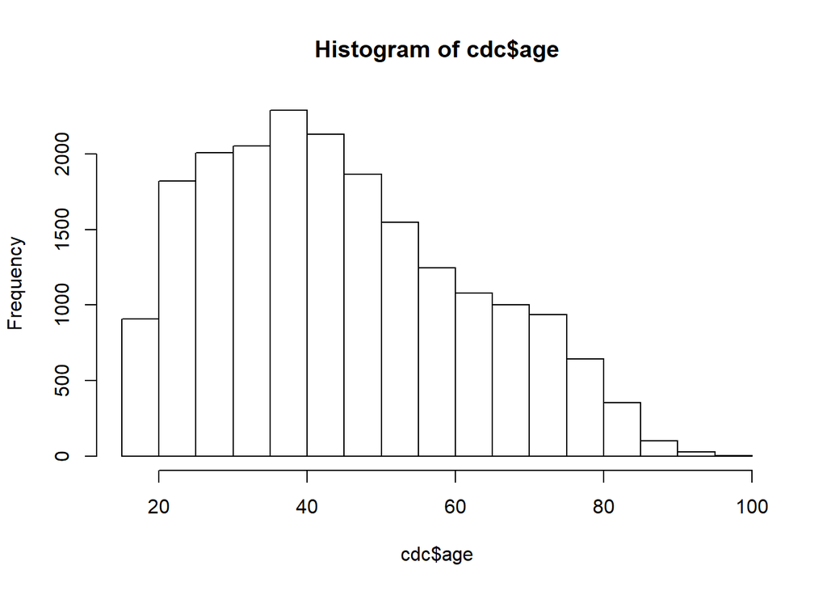

```r
  hist(cdc$age)
```

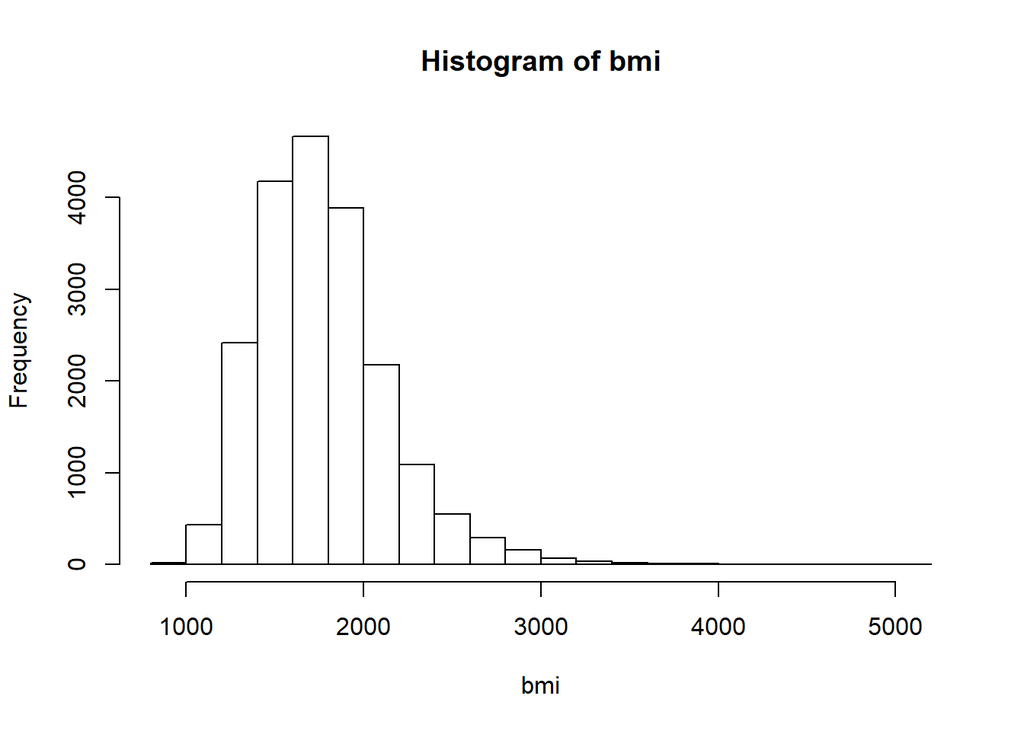

```r
  hist(bmi)
```

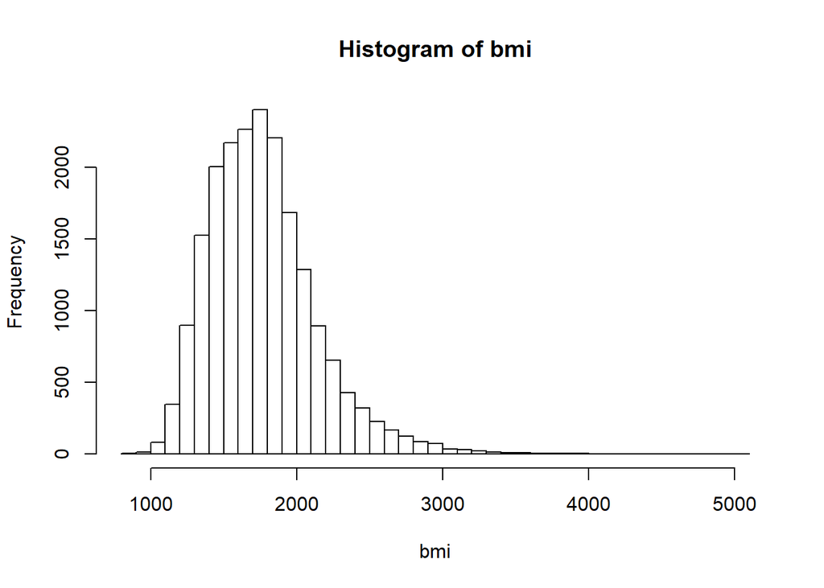

```r
  hist(bmi, breaks = 50)
```

Sua Vez 1. Crie um gráfico de dispersão da variável peso em relação ao peso desejado. Defina a relação entre essas duas variáveis.

Como criar um gráfico de dispersão?

```r
  head(cdc)
```

```
##     genhlth exerany hlthplan smoke100 height weight wtdesire age gender
## 1      good       0        1        0     70    175      175  77      m
## 2      good       0        1        1     64    125      115  33      f
## 3      good       1        1        1     60    105      105  49      f
## 4      good       1        1        0     66    132      124  42      f
## 5 very good       0        1        0     61    150      130  55      f
## 6 very good       1        1        0     64    114      114  55      f
```

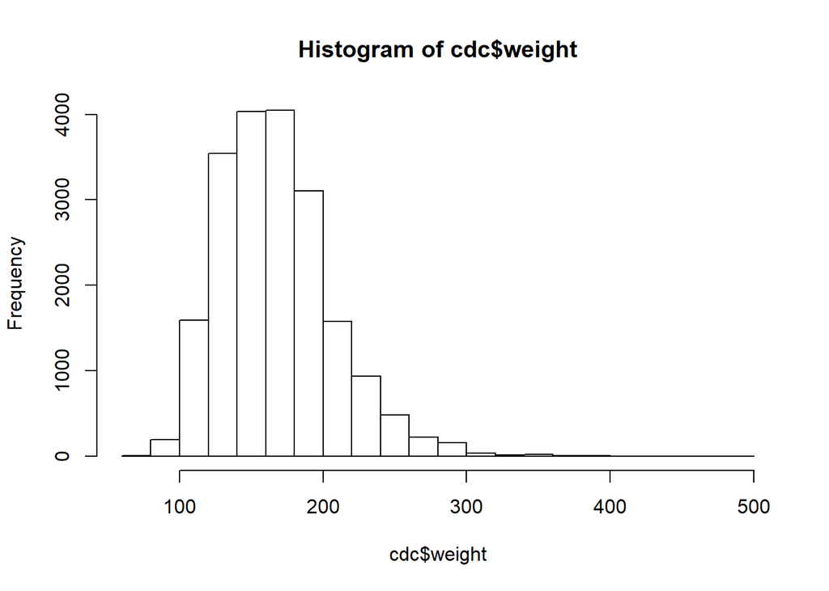

```r
  hist(cdc$weight)
```

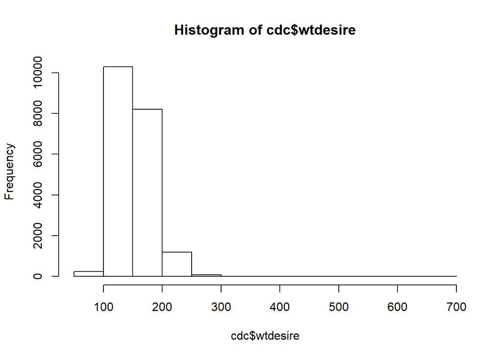

```r
  hist(cdc$wtdesire)
```

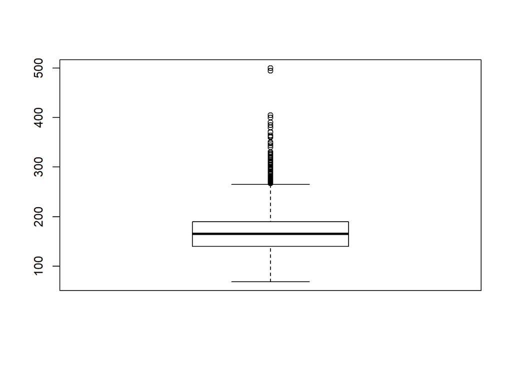

```r
  boxplot(cdc$weight)
```

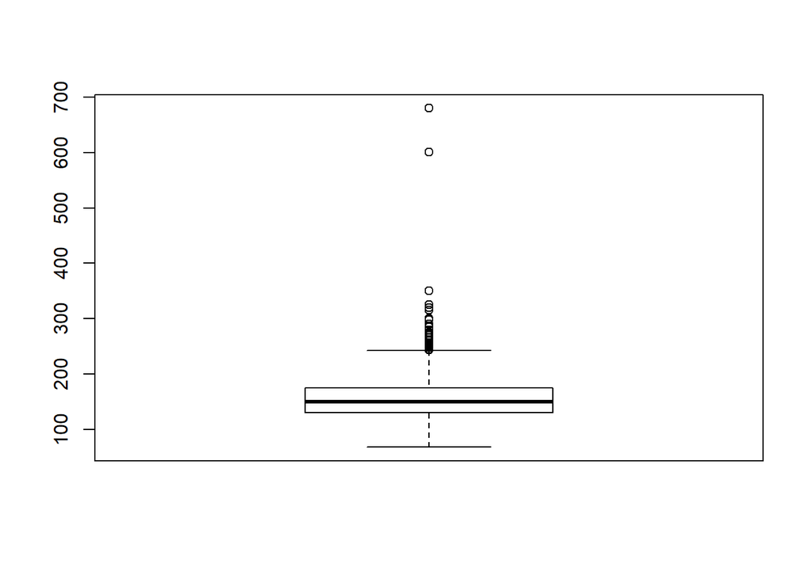

```r
  boxplot(cdc$wtdesire)
```

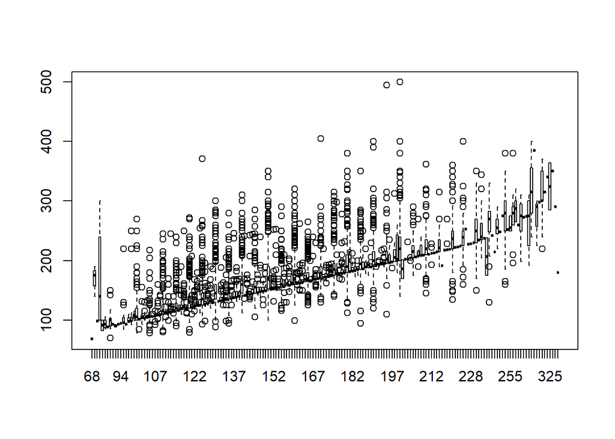

```r
  boxplot(cdc$weight ~ cdc$wtdesire)
```

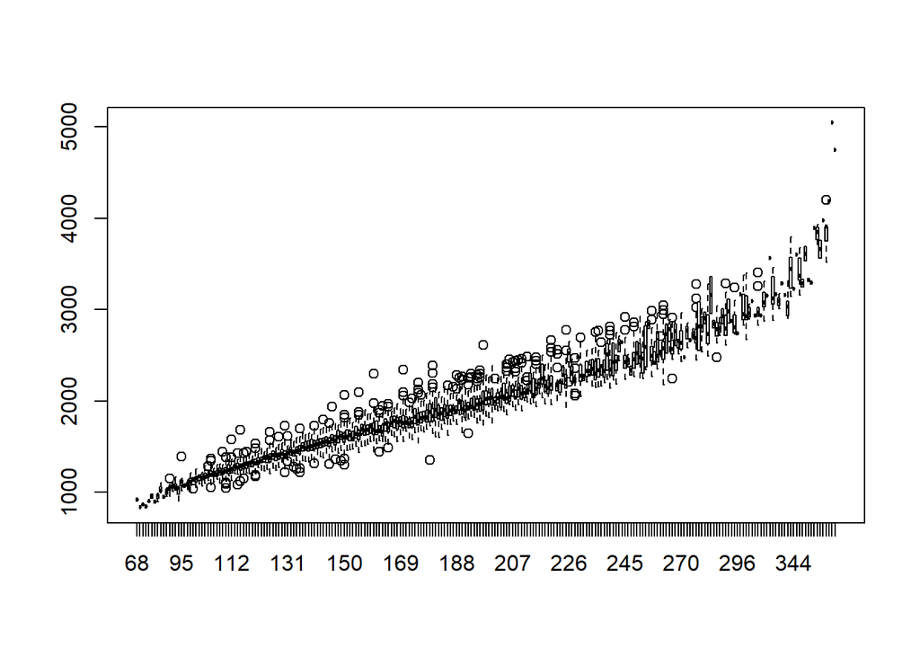

```r
  boxplot(bmi ~ cdc$weight)
```

2. Vamos considerar uma nova variável: a diferença entre o peso desejado (wtdesire) e o peso atual (weight). Crie esta nova variável subtraindo as duas colunas na base de dados e atribuindo-as a um novo objeto chamado wdiff.

```r
wdiff = cdc$wtdesire - cdc$weight

head(wdiff)
```

```
## [1]   0 -10   0  -8 -20   0
```

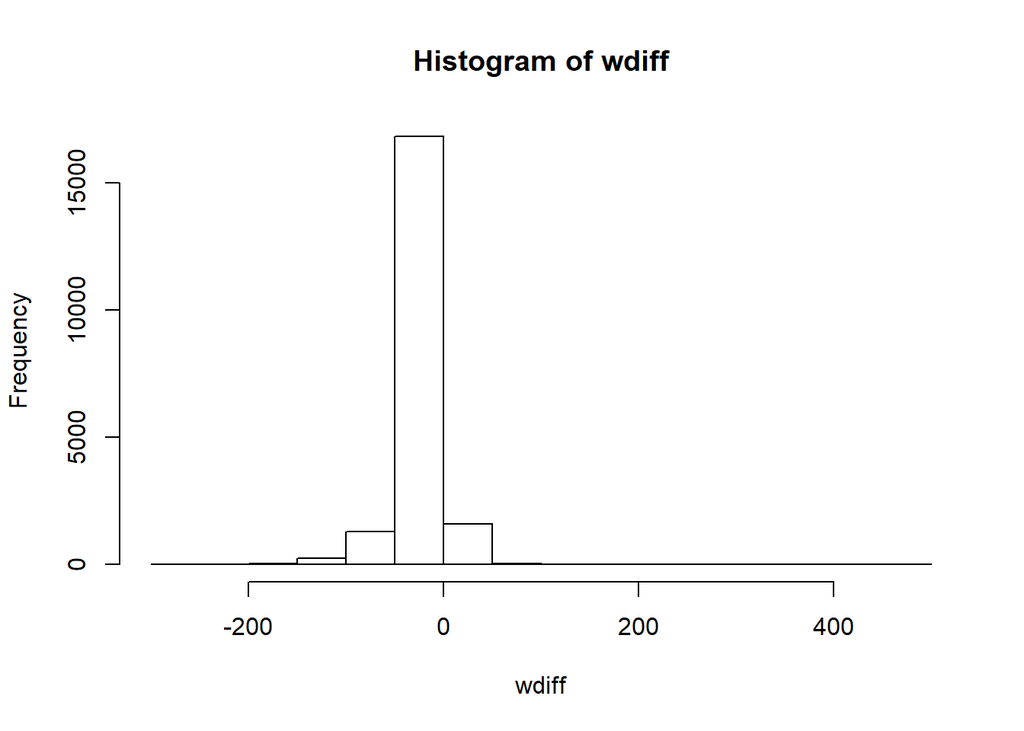

```r
hist(wdiff)
```

3. Que tipo de dado está contido na variável wdiff? Se uma observação de wdiff é 0, o que isso implica com relação ao peso atual e desejado de uma pessoas? E se o valor de wdiff for positivo ou negativo?

Tipo Numerico(ou quantitativo). Se uma observação de wdiff é 0 significa que a pessoa que o peso desejado é igual ao peso atual. Se for positivo está abaixo do peso desejado, mas se for negativo está acima do peso.

4. Descreva a distribuição de wdiff em termos de seu centro, forma e variação, incluindo qualquer gráfico que você usar. O que isso nos diz sobre como as pessoas se sentem a respeito do seu peso atual?

A respeito do seu peso as pessoas se sentem acima do peso desejado. Utilizando a média, mediana e o hitograma podemos verificar isto.

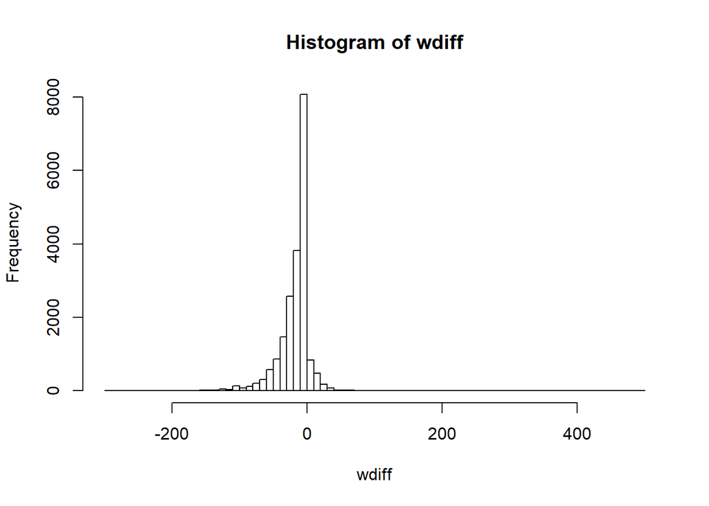

```r
hist(wdiff, breaks = 100)
```

```r
summary(wdiff)
```

```
##    Min. 1st Qu.  Median    Mean 3rd Qu.    Max.
## -300.00  -21.00  -10.00  -14.59    0.00  500.00
```

```r
mean(wdiff)
```

```
## [1] -14.5891
```

```r
var(wdiff)
```

```
## [1] 578.2032
```

```r
median(wdiff)
```

```
## [1] -10
```

```r
summary(wdiff)
```

```
##    Min. 1st Qu.  Median    Mean 3rd Qu.    Max.
## -300.00  -21.00  -10.00  -14.59    0.00  500.00
```

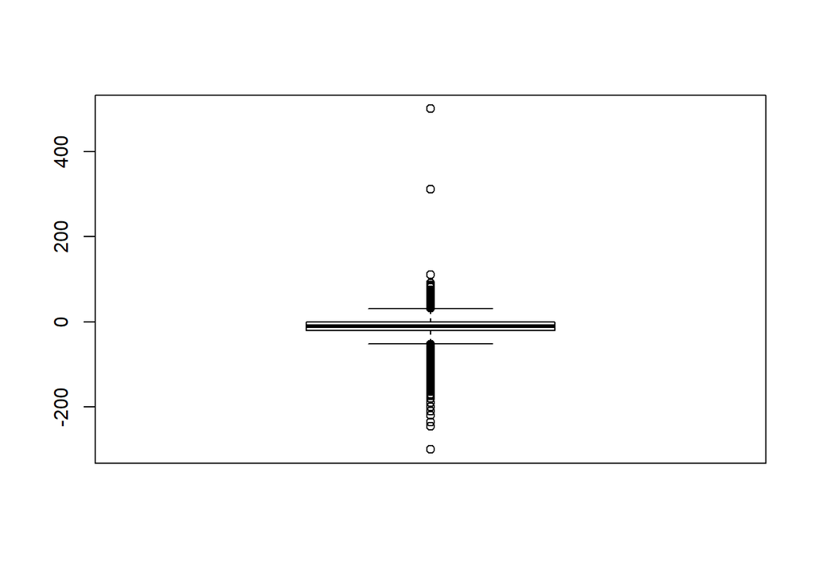

```r
boxplot(wdiff)
```

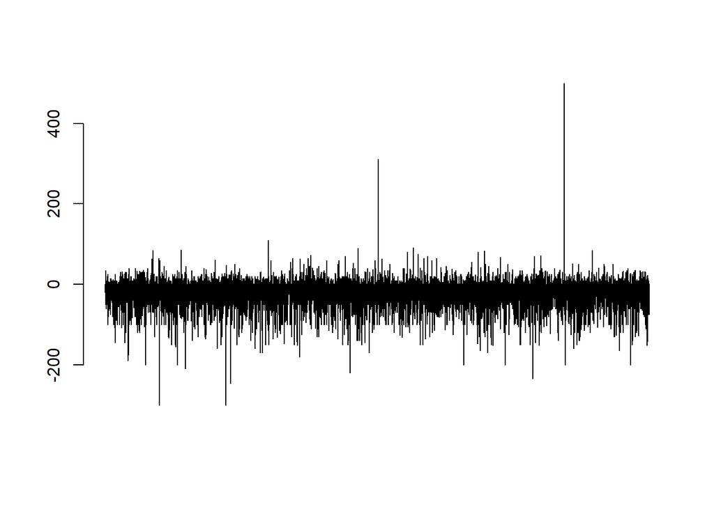

```r
barplot(wdiff)
```

5. Utilizando sumários numéricos e um gráfico de caixas lado-a-lado, determine se homens tendem a ver seu peso diferentemente das mulheres.

Os homens tendem a desejar um peso mais alto que o das mulheres.

```r
  summary(cdc$wtdesire)
```

```
##    Min. 1st Qu.  Median    Mean 3rd Qu.    Max.
##    68.0   130.0   150.0   155.1   175.0   680.0
```

```r
  summary(wdiff)
```

```
##    Min. 1st Qu.  Median    Mean 3rd Qu.    Max.
## -300.00  -21.00  -10.00  -14.59    0.00  500.00
```

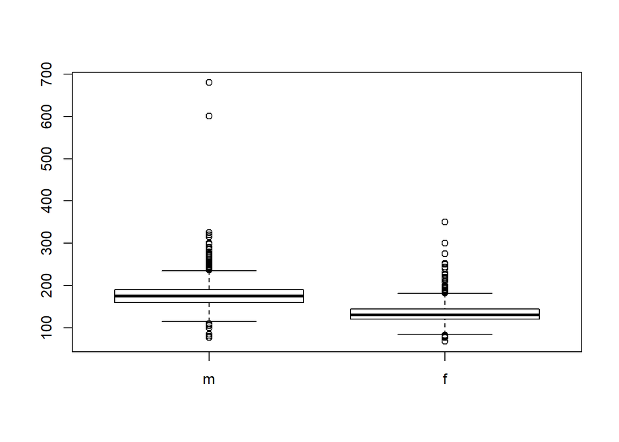

```r
  boxplot(cdc$wtdesire ~ cdc$gender)
```

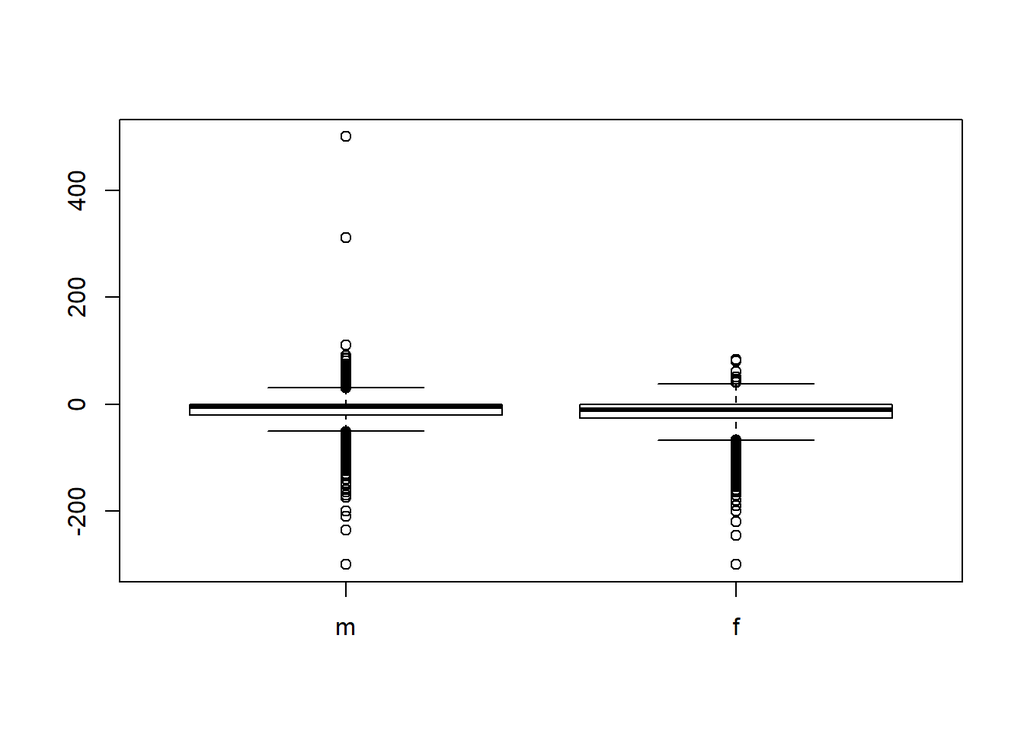

```r
  boxplot(wdiff ~ cdc$gender)
```

6. Agora chegou a hora de usar a criatividade. Encontre a média e o desvio padrão de weight e determine qual a proporção de pesos que estão a um desvio padrão da média.
7. Quais conceitos do livro são abordados neste laboratório? Quais conceitos, se houver algum, que não são abordados no livro? Você viu esses conceito em algum outro lugar, p.e., aulas, seções de discussão, laboratórios anteriores, ou tarefas de casa? Seja específico em sua resposta.